# Chapter-2-Simple linear regression

Waheeb Algabri

2024-02-02

### 1.The dataset teengamb concerns a study of teenage gambling in Britain. Fit a regression model with the expenditure on gambling as the response and the sex, status, income and verbal score as predictors.

```r
library(faraway)
data <- (teengamb)
head(data)
```

```
##   sex status income verbal gamble
## 1   1     51   2.00      8    0.0
## 2   1     28   2.50      8    0.0
## 3   1     37   2.00      6    0.0
## 4   1     28   7.00      4    7.3
## 5   1     65   2.00      8   19.6
## 6   1     61   3.47      6    0.1
```

**(a) What percentage of variation in the response is explained by these predictors?**

```r
# Assuming 'teengamb' is your dataset
# Fit a regression model
model <- lm(gamble ~ sex + status + income + verbal, data = teengamb)


# Print the summary of the model
summary(model)
```

```
##
## Call:
## lm(formula = gamble ~ sex + status + income + verbal, data = teengamb)
##
## Residuals:
##     Min      1Q  Median      3Q     Max
## -51.082 -11.320  -1.451   9.452  94.252
##
## Coefficients:
##              Estimate Std. Error t value Pr(>|t|)
## (Intercept)  22.55565   17.19680   1.312   0.1968
## sex         -22.11833    8.21111  -2.694   0.0101 *
## status        0.05223    0.28111   0.186   0.8535
## income        4.96198    1.02539   4.839 1.79e-05 ***
## verbal       -2.95949    2.17215  -1.362   0.1803
## ---
## Signif. codes:  0 '***' 0.001 '**' 0.01 '*' 0.05 '.' 0.1 ' ' 1
##
## Residual standard error: 22.69 on 42 degrees of freedom
## Multiple R-squared:  0.5267, Adjusted R-squared:  0.4816
## F-statistic: 11.69 on 4 and 42 DF,  p-value: 1.815e-06
```

```r
# Extract and print R-squared
r_squared <- summary(model)$r.squared
cat("Percentage of variation explained by predictors:", round(r_squared * 100, 2), "%\n")
```

```
## Percentage of variation explained by predictors: 52.67 %
```

**(b) Which observation has the largest (positive) residual? Give the case number.**

```r
# Extract residuals
residuals <- residuals(model)

# Find the index of the observation with the largest positive residual
max_residual_index <- which.max(residuals)

# Print the case number
cat("Observation with the largest positive residual (case number):", max_residual_index, "\n")
```

```
## Observation with the largest positive residual (case number): 24
```

**(c) Compute the mean and median of the residuals.**

```r
# Compute mean and median of residuals
mean_residual <- mean(residuals)
median_residual <- median(residuals)

# Print the results
cat("Mean of residuals:", mean_residual, "\n")
```

```
## Mean of residuals: -3.065293e-17
```

```r
cat("Median of residuals:", median_residual, "\n")
```

```
## Median of residuals: -1.451392
```

**(d) Compute the correlation of the residuals with the fitted values.**

```r
# Extract residuals and fitted values
residuals <- residuals(model)
fitted_values <- fitted(model)

# Compute the correlation
correlation_resid_fitted <- cor(residuals, fitted_values)

# Print the result
cat("Correlation of residuals with fitted values:", correlation_resid_fitted, "\n")
```

```
## Correlation of residuals with fitted values: -1.070659e-16
```

**(e) Compute the correlation of the residuals with the income**.

```r
# Extract residuals and income
residuals <- residuals(model)
income <- teengamb$income
# Compute the correlation
correlation_resid_income <- cor(residuals, income)

# Print the result
cat("Correlation of residuals with income:", correlation_resid_income, "\n")
```

```
## Correlation of residuals with income: -7.242382e-17
```

**(f) For all other predictors held constant, what would be the difference in predicted expenditure on gambling for a male compared to a female?**

```r
# Extract coefficients
coefficients <- coef(model)

# Find the coefficient for 'sex'
coefficient_sex <- coefficients['sex']

# Print the difference in predicted expenditure for male compared to female
cat("Difference in predicted expenditure for male compared to female:", coefficient_sex, "\n")
```

```
## Difference in predicted expenditure for male compared to female: -22.11833
```

### 2. The dataset uswages is drawn as a sample from the Current Population Survey in 1988. Fit a model with weekly wages as the response and years of education and experience as predictors. Report and give a simple interpretation to the regression coefficient for years of education. Now fit the same model but with logged weekly wages. Give an interpretation to the regression coefficient for years of education. Which interpretation is more natural?

```r
uswages_1 <-(uswages)
head(uswages)
```

```
##         wage educ exper race smsa ne mw so we pt
## 6085  771.60   18    18    0    1  1  0  0  0  0
## 23701 617.28   15    20    0    1  0  0  0  1  0
## 16208 957.83   16     9    0    1  0  0  1  0  0
## 2720  617.28   12    24    0    1  1  0  0  0  0
## 9723  902.18   14    12    0    1  0  1  0  0  0
## 22239 299.15   12    33    0    1  0  0  0  1  0
```

```r
# Fit a regression model with weekly wages as the response
model_wages <- lm(wage ~ educ + exper, data = uswages_1)

# Print the summary of the model
summary(model_wages)
```

```
##
## Call:
## lm(formula = wage ~ educ + exper, data = uswages_1)
##
## Residuals:
##     Min      1Q  Median      3Q     Max
## -1018.2  -237.9   -50.9   149.9  7228.6
##
## Coefficients:
##              Estimate Std. Error t value Pr(>|t|)
## (Intercept) -242.7994    50.6816  -4.791 1.78e-06 ***
## educ          51.1753     3.3419  15.313  < 2e-16 ***
## exper          9.7748     0.7506  13.023  < 2e-16 ***
## ---
## Signif. codes:  0 '***' 0.001 '**' 0.01 '*' 0.05 '.' 0.1 ' ' 1
##
## Residual standard error: 427.9 on 1997 degrees of freedom
## Multiple R-squared:  0.1351, Adjusted R-squared:  0.1343
## F-statistic:   156 on 2 and 1997 DF,  p-value: < 2.2e-16
```

we’ll fit the same model but with logged weekly wages and interpret the regression coefficient for years of education.

```r
# Fit a regression model with logged weekly wages as the response
model_logged_wages <- lm(log(wage) ~ educ + exper, data = uswages_1)

# Print the summary of the model
summary(model_logged_wages)
```

```
##
## Call:
## lm(formula = log(wage) ~ educ + exper, data = uswages_1)
##
## Residuals:
##     Min      1Q  Median      3Q     Max
## -2.7533 -0.3495  0.1068  0.4381  3.5699
##
## Coefficients:
##             Estimate Std. Error t value Pr(>|t|)
## (Intercept) 4.650319   0.078354   59.35   <2e-16 ***
## educ        0.090506   0.005167   17.52   <2e-16 ***
## exper       0.018079   0.001160   15.58   <2e-16 ***
## ---
## Signif. codes:  0 '***' 0.001 '**' 0.01 '*' 0.05 '.' 0.1 ' ' 1
##
## Residual standard error: 0.6615 on 1997 degrees of freedom
## Multiple R-squared:  0.1749, Adjusted R-squared:  0.174
## F-statistic: 211.6 on 2 and 1997 DF,  p-value: < 2.2e-16
```

```r
# Interpretation of the coefficient for 'educ' in the logged model
coefficient_logged = coef(model_logged_wages)["educ"]
percentage_change = (exp(coefficient_logged) - 1) * 100
cat("Percentage change in weekly wages for a one-unit increase in years of education:", percentage_change, "%\n")
```

```
## Percentage change in weekly wages for a one-unit increase in years of education: 9.472838 %
```

### Exersises in extended linear model with R chapter 2

**1. The dataset wbca comes from a study of breast cancer in Wisconsin. There are 681 cases of potentially cancerous tumors of which 238 are actually malignant. Determining whether a tumor is really malignant is traditionally determined by an invasive surgical procedure. The purpose of this study was to determine whether a new procedure called fine needle aspiration, which draws only a small sample of tissue, could be effective in determining tumor status.**

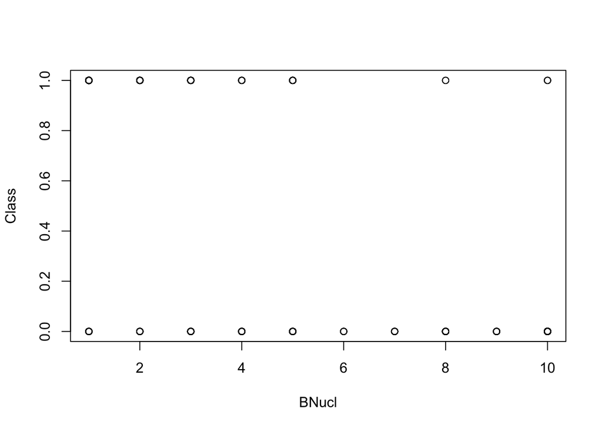

```r
plot(Class ~ BNucl, wbca)
```

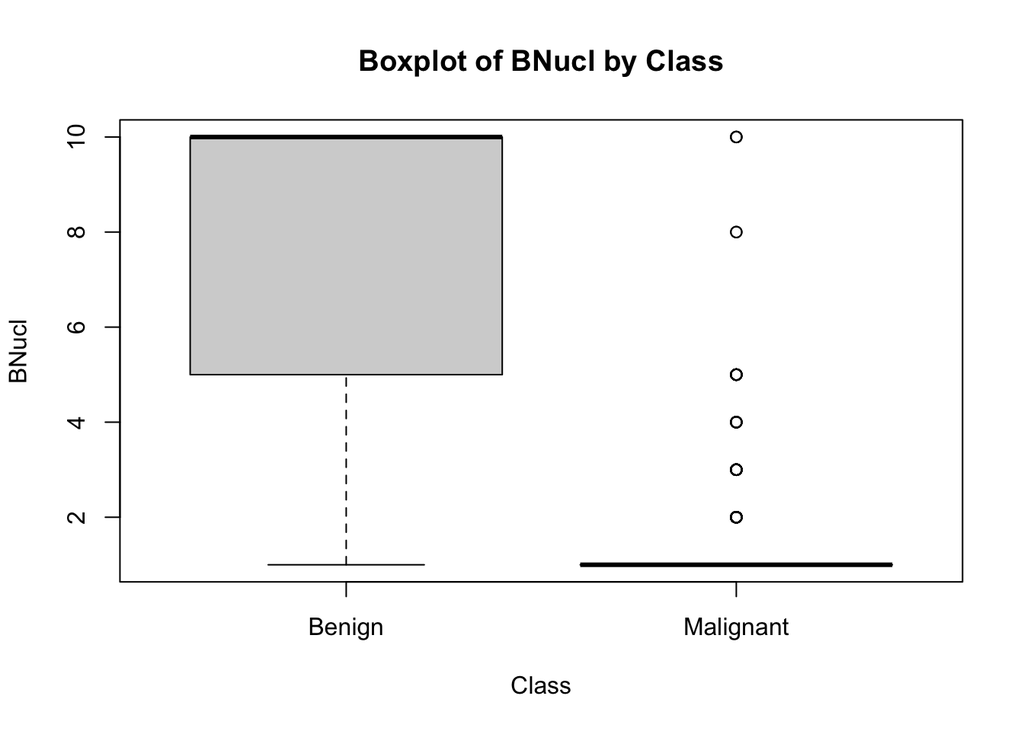

```r
# ii. Create a factor version of the response and produce boxplots
wbca$ClassFactor <- factor(wbca$Class, levels = c(0, 1), labels = c("Benign", "Malignant"))
boxplot(BNucl ~ ClassFactor, data = wbca, xlab = "Class", ylab = "BNucl", main = "Boxplot of BNucl by Class")
```

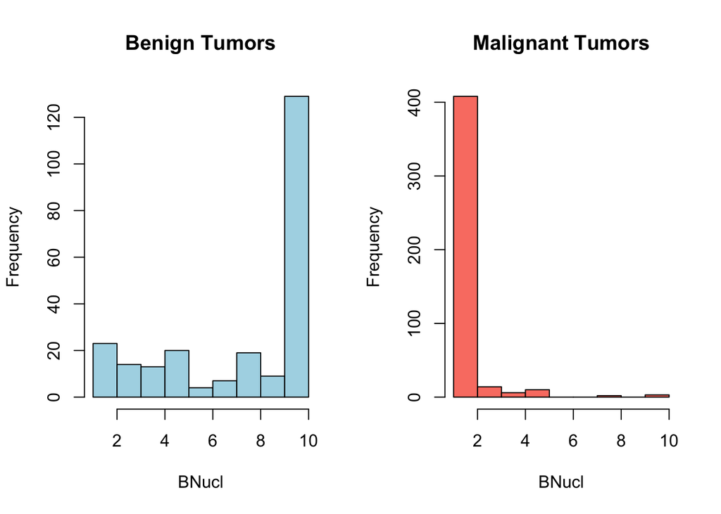

```r
# iv. Produce a version of the interleaved histogram
par(mfrow = c(1, 2))
hist(wbca$BNucl[wbca$ClassFactor == "Benign"], col = "lightblue", main = "Benign Tumors", xlab = "BNucl")
hist(wbca$BNucl[wbca$ClassFactor == "Malignant"], col = "salmon", main = "Malignant Tumors", xlab = "BNucl")
```

```r
# c. Fit a binary regression with Class as the response and the other nine variables as predictors
binary_model <- glm(Class ~ Adhes + BNucl + Chrom + Epith + Mitos + NNucl + Thick + UShap + USize, data = wbca, family = binomial)
summary(binary_model)
```

```
##
## Call:
## glm(formula = Class ~ Adhes + BNucl + Chrom + Epith + Mitos +
##     NNucl + Thick + UShap + USize, family = binomial, data = wbca)
##
## Deviance Residuals:
##      Min        1Q    Median        3Q       Max
## -2.48282  -0.01179   0.04739   0.09678   3.06425
##
## Coefficients:
##             Estimate Std. Error z value Pr(>|z|)
## (Intercept) 11.16678    1.41491   7.892 2.97e-15 ***
## Adhes       -0.39681    0.13384  -2.965  0.00303 **
## BNucl       -0.41478    0.10230  -4.055 5.02e-05 ***
## Chrom       -0.56456    0.18728  -3.014  0.00257 **
## Epith       -0.06440    0.16595  -0.388  0.69795
## Mitos       -0.65713    0.36764  -1.787  0.07387 .
## NNucl       -0.28659    0.12620  -2.271  0.02315 *
## Thick       -0.62675    0.15890  -3.944 8.01e-05 ***
## UShap       -0.28011    0.25235  -1.110  0.26699
## USize        0.05718    0.23271   0.246  0.80589
## ---
## Signif. codes:  0 '***' 0.001 '**' 0.01 '*' 0.05 '.' 0.1 ' ' 1
##
## (Dispersion parameter for binomial family taken to be 1)
##
##     Null deviance: 881.388  on 680  degrees of freedom
## Residual deviance:  89.464  on 671  degrees of freedom
## AIC: 109.46
##
## Number of Fisher Scoring iterations: 8
```

```r
# d. Use AIC for variable selection
selected_model <- step(binary_model, direction = "both", trace = FALSE)
summary(selected_model)
```

```
##
## Call:
## glm(formula = Class ~ Adhes + BNucl + Chrom + Mitos + NNucl +
##     Thick + UShap, family = binomial, data = wbca)
##
## Deviance Residuals:
##      Min        1Q    Median        3Q       Max
## -2.44161  -0.01119   0.04962   0.09741   3.08205
##
## Coefficients:
##             Estimate Std. Error z value Pr(>|z|)
## (Intercept)  11.0333     1.3632   8.094 5.79e-16 ***
## Adhes        -0.3984     0.1294  -3.080  0.00207 **
## BNucl        -0.4192     0.1020  -4.111 3.93e-05 ***
## Chrom        -0.5679     0.1840  -3.085  0.00203 **
## Mitos        -0.6456     0.3634  -1.777  0.07561 .
## NNucl        -0.2915     0.1236  -2.358  0.01837 *
## Thick        -0.6216     0.1579  -3.937 8.27e-05 ***
## UShap        -0.2541     0.1785  -1.423  0.15461
## ---
## Signif. codes:  0 '***' 0.001 '**' 0.01 '*' 0.05 '.' 0.1 ' ' 1
##
## (Dispersion parameter for binomial family taken to be 1)
##
##     Null deviance: 881.388  on 680  degrees of freedom
## Residual deviance:  89.662  on 673  degrees of freedom
## AIC: 105.66
##
## Number of Fisher Scoring iterations: 8
```

```r
# e. Compute number of errors with the reduced model
predicted_probs <- predict(selected_model, type = "response")
predicted_class <- ifelse(predicted_probs > 0.5, 1, 0)
conf_matrix <- table(predicted_class, wbca$Class)
errors <- sum(conf_matrix[c(2, 3)])  # Sum of false positives and false negatives
cat("Number of errors:", errors, "\n")
```

```
## Number of errors: 20
```